# Homework 5

## CS: Exercise 4.4

**Suppose that you have $n$ independent measurements of times between major aircraft disasters, $t_i$, and believe that the probability density function for the $t_i$’s is of the form: $f(t) = k e^{-\lambda t^2}$ $t \geq 0$ where $\lambda$ and $k$ are the same for all $i$.**

**(a) By considering the normal p.d.f., show that $k = \sqrt{4 \lambda / \pi}$.**

The normal p.d.f is :

$$f(t) = \frac{1}{\sqrt{2\pi\sigma^2}}\exp\{-\frac{(x - \mu)^2}{2\sigma^2}\})$$
By considering the mean of this normal p.d.f is 0 ($\mu = 0$) and $x$ takes only positive values, since $t = x - \mu = x \geq 0$ :
$$f(t) = \frac{1}{\sqrt{2\pi\sigma^2}}\exp\{-\frac{t^2}{2\sigma^2}\})$$

From this equation, we can consider $k = \frac{1}{\sqrt{2\pi\sigma^2}}$ and $\lambda = \frac{1}{2\sigma^2}$, then the f(t) will be as the p.d.f of $t_i$:

$$f(t) = k e^{-\lambda t^2}$$
.

Now, to prove that $k = \sqrt{4 \lambda / \pi}$, we can write $k$ with rescpect to $\lambda$ :

$$k = \frac{1}{\sqrt{2\pi\sigma^2}} = \sqrt{\frac{1}{2\pi\sigma^2}} = \sqrt{\frac{1}{2\sigma^2}\frac{1}{\pi}} = \sqrt{\lambda/\pi}$$

In this case, we can see that $k = \sqrt{ \lambda / \pi}$ , and to make it $\sqrt{4 \lambda / \pi}$ we have to multiply the normal p.d.f by 2, such that :

$$f(t) = \frac{2}{\sqrt{2\pi\sigma^2}}\exp\{-\frac{(x - \mu)^2}{2\sigma^2}\})$$

where again $t = x - \mu$ , $k = \frac{2}{\sqrt{2\pi\sigma^2}}$ and $\lambda = \frac{1}{2\sigma^2}$. And in this case :

$$k = \frac{2}{\sqrt{2\pi\sigma^2}} = \sqrt{\frac{4}{2\pi\sigma^2}} = \sqrt{4 \frac{1}{2\sigma^2}\frac{1}{\pi}} = \sqrt{4\lambda/\pi}$$

**(b) Obtain a maximum likelihood estimator for $\lambda$.**

To obtain the MLE for $\lambda$ :

1. Compute the likelihood function for the function f(t):

$$L(t) = \prod_{i = 0}^nke^{-\lambda t_i^2} = k^n \prod_{i = 0}^n e^{-\lambda t_i^2}$$

2. Take the logarithm of the Likelihood function to get the log likelihood :

$$\ell(t) = \log (k^n \prod_{i = 0}^n e^{-\lambda t_i^2}) = \log (k^n) + \log (\prod_{i = 0}^n e^{-\lambda t_i^2}) =n \log(k) - \lambda \sum_{i = 0}^n t_i^2 = n \log(\sqrt{4\lambda/\pi}) - \lambda \sum_{i = 0}^n t_i^2$$

3. Set the derivative of the log likelihood to 0:

$$\frac{d\ell(t)}{d\lambda} = \frac{n}{2\lambda} - \sum_{i = 0}^n t_i^2 = 0$$
$$\frac{n}{2\lambda} = \sum_{i = 0}^n t_i^2$$

$$\lambda = \frac{n}{2 \sum_{i = 0}^n t_i^2}$$
which is the Maximum Likelihood estimator for $\lambda$.

**(c) Given observations of $T_i$ (in days) of: 243, 14, 121, 63, 45, 407 and 34, use a generalised likelihood ratio test to test $H_0 : \lambda = 10^{-4}$ against the alternative of no restriction on $\lambda$ at the 5% significance level. Note that if $V ∼ χ_{1}^2$ then $Pr[V ≤ 3.841] = 0.95$.**

The log_likelihood is : $\ell(t) = n \log(\sqrt{4\lambda/\pi}) - \lambda \sum_{i = 0}^n t_i^2$, we need to replace $\lambda$ parameter once with the value of null hypothesis $\lambda = 10^{-4}$ and the other with the value of MLE that we have found before as an alternative of no restriction on $\lambda$.

Then, the likelihood ratio test $LRT$ would become :
$$W(H_0) = 2 \{\ell(\hat\lambda) - \ell(\hat\lambda_{H_0})\}$$

```r
log_likelihood <- function(data, param){
   length(data) * log(sqrt(4 * param / pi)) - param * sum(data^2)
 }

obs <- c(243, 14, 121, 63, 45, 407, 34)

lambda_mle <- length(obs) / (2 * sum(obs^2))
print(paste("MLE for lambda = ", lambda_mle))
```

```
## [1] "MLE for lambda =  1.41881346656667e-05"
```

```r
l_H0 <- log_likelihood(obs, 10^-4)
l_mle <- log_likelihood(obs, lambda_mle)

lrt <- 2 * (l_mle - l_H0)

p_lrt <- pchisq(lrt, df=1, lower.tail = FALSE)
print(paste("p-value of Likelihood ratio test :", p_lrt))
```

```
## [1] "p-value of Likelihood ratio test : 8.59271921510837e-08"
```

Based on the p-value, as it is too low, we reject the null hypothesis. AS, also we can see that the MLE for $\lambda$ is different from $10^{-4}$.

## BC: Exercise 2.2

**Consider the following experiment. Hold a penny on edge on a flat hard surface, and spin it with your fingers. Let $p$ denote the probability that it lands heads. To estimate this probability, we will use a histogram to model our prior beliefs about $p$. Divide the interval $[0,1]$ into the ten subintervals $[0, 0.1]$, $[0.1, 0.2]$, $...$, $[0.9, 1]$, and specify probabilities that p is in each interval. Next spin the penny 20 times and count the number of successes (heads) and failures (tails). Simulate from the posterior distribution by (1) computing the posterior density of $p$ on a grid of values on $(0, 1)$ and (2) taking a simulated sample with replacement from the grid. (The functions `histprior` and `sample` are helpful in this computation.) How have the interval probabilities changed on the basis of your data?**

At first, considering the ten subintervals $[0, 0.1]$, $[0.1, 0.2]$, $...$, $[0.9, 1]$, let’s consider the center of these subintervals

```r
library(LearnBayes)

midp<-seq(0.05,0.95, by=0.1)
midp
```

```
##  [1] 0.05 0.15 0.25 0.35 0.45 0.55 0.65 0.75 0.85 0.95
```

Once defined these points we can express our prior beliefs about $p$ by using an histogram model that associate to each subinterval a probability by using the `histprior` function. Since we don’t know in advance if the coin is fair or not, we assume that the probability that it lands heads is equal for every subinterval.

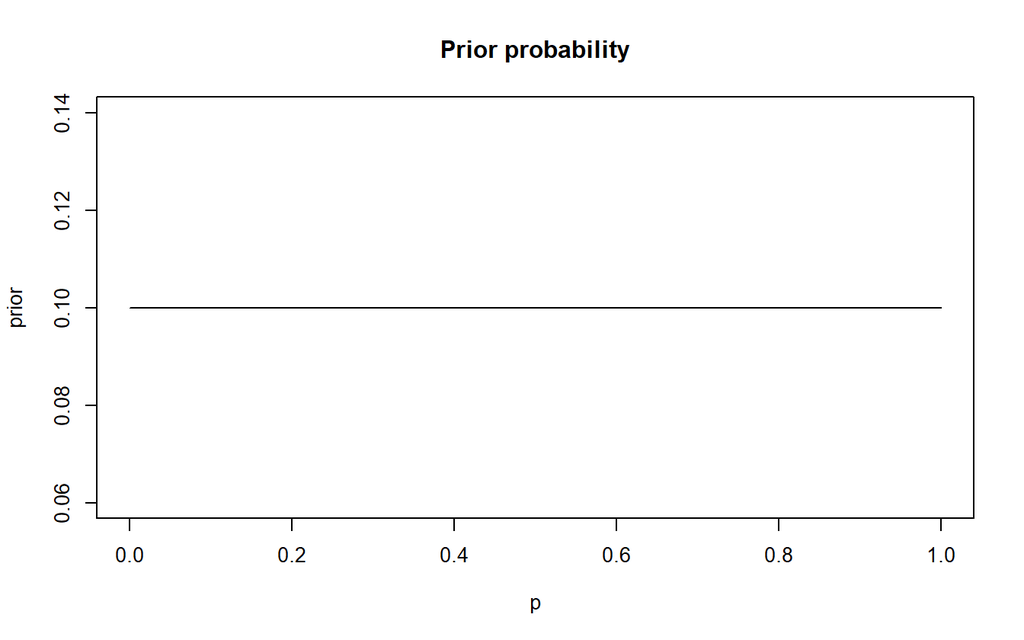

```r
prior <- c(.1,.1,.1,.1,.1,
           .1,.1,.1,.1,.1)
p=seq(0,1,length=500)

prior<-histprior(midpts = midp, prob = prior,p)

plot(p,prior, type = "l", main = "Prior probability", xlab = "p")
```

After having stated our prior beliefs, we proceed by the experimental evaluation. We tossed a coin for 20 times and we reported in the following table the results:

| Throw | Result |
| --- | --- |
| 1 | Head |
| 2 | Tail |
| 3 | Tail |
| 4 | Head |
| 5 | Tail |
| 6 | Head |
| 7 | Head |
| 8 | Head |
| 9 | Tail |
| 10 | Tail |
| 11 | Head |
| 12 | Tail |
| 13 | Head |
| 14 | Head |
| 15 | Tail |
| 16 | Head |
| 17 | Tail |
| 18 | Tail |
| 19 | Head |
| 20 | Head |

**Total Heads ($s$)**: 11 **Total Tails ($f$)**: 9

We now update our knowledge of $p$ by applying the Bayes’ theorem:

$$P(p|s) = \frac{P(s | p)P(p)}{\int dp P(s| p)P(p) }.$$

For what concerns the likelihood, we assume that the probability $P(s | p)$ to have $s$ successes in a 20-throw experiment follows a Binomial distribution:

$$P(s | p) = \binom{20}{s} ~ p^s (1-p)^{20-s}$$
.

We evaluate this posterior in two different ways:

- evaluating the posterior $P(p|s)$ on a sequence of 500 elements that goes from 0 till 1.

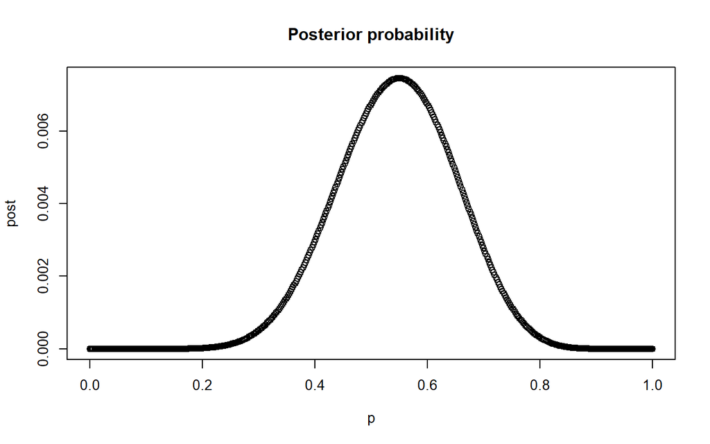

```r
success<-11
failure<-9

like<-choose(20, success)*p^(success)*(1-p)^(failure)
post<-like*prior
post<-post/sum(post)

plot(p, post, main="Posterior probability", xlab="p")
```

- sampling $p$ with replacement with probability equal to the posterior.

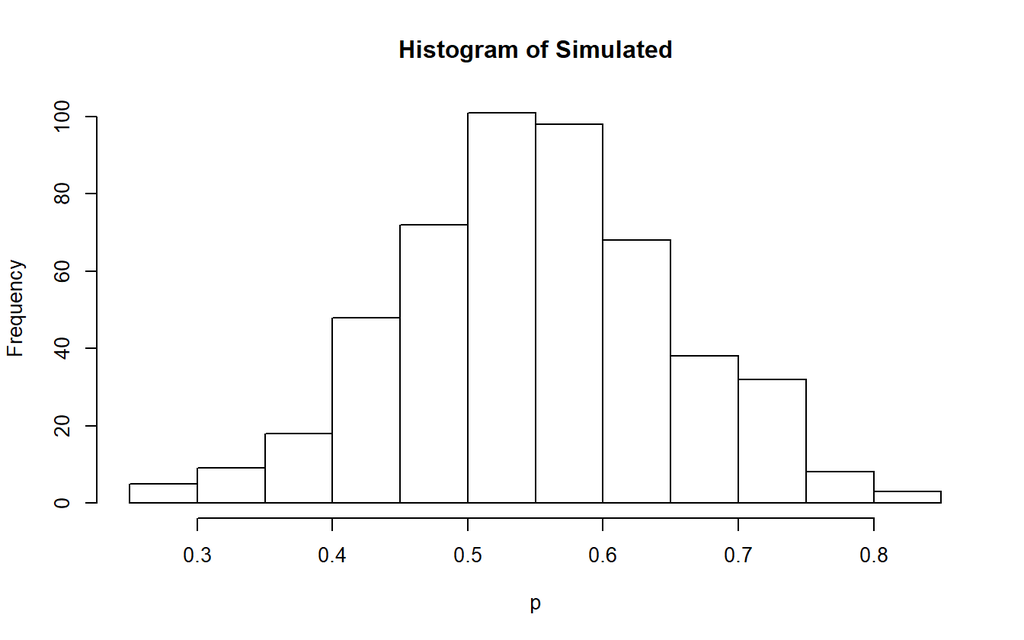

```r
Simulated<-sample(p,replace=TRUE, prob=post)
hist(Simulated, xlab='p')
```

After the experiment, our notion about the probability $p$ is improved. The posterior distribution on both cases suggests that the probability of having head is around $0.5$ and this lead to think that the coin is fair.

## DAAG: Exercise 7.7